# OM337: Supply Chain Analytics

Solution to Assignment #8

In this laboratory we explore utilization of Dynamic Regression (Regression with ARIMA Errors) to develop point of sale demand forecasting models (forecasting for distribution). We use as an example the demand of âSkippyâ brand peanut butter (a Unilever Corp. product) as observed in a supermarket chain (that shall remain anonymous) operating in the Chicago metropolitan area.

The sales data is provided in CSV format in the file **“Peanut Butter Chicago.csv”**. As this is an individual skill-building assignment (as opposed to an open-ended team assignment), and I would like to achieve some degree of convergence in your answers, I have also provided a preprocessing script for the assignment. The data set corresponds to the total weekly sales of peanut butter for the supermarket chain, not the individual stores. As you can observe from the file, the data corresponds to a combination of multiple brands as well as the supermarket private label (generic) in sizes ranging from 0.75 to 1.5 lbs.

The data includes the following information for each individual stock keeping unit (SKU) as identified by its UPC code on each week in the data file:

- VEND Number identifying the product vendor (48001 corresponds to Unilever).
- UPC The productâs universal product code (bar code)
- UNITS Sales volume
- DOLLARS Dollar sales revenue
- VOL_EQ Weight in pounds of a units sold
- PPU Price per unit $/package
- F Factor specifying advertising in the store weekly flyer:
  - F = âA+â Large size ad.
  - F = âAâ Medium size ad.
  - F = âBâ Small size ad.
- D Factor specifying In-Store Display
  - D = 0 No In-Store Display
  - D = 1 Minor In-Store Display
  - D = 2 Major In-Store Display

To simplify the modeling process (and the assignment) in the preprocessing script I lumped all products into just three aggregate products (sub-categories): âSKâ includes all Skippy brand products, âOBâ includes all other branded products and âPLâ includes all private label (or generic) products. For each of the three aggregate products I obtained total sales (volume), average sale prices, and volume-weighted averages of the advertising and display variables (F and D).

```r
library(fpp2)
library(reshape)
library(dplyr)
library(glmnet)

# Data Pre-Processing
#
PBS <- read.csv("Peanut Butter Chicago.csv")[,-1] %>%
  mutate( PPU2 = DOLLARS/UNITS,
          F_LSA=ifelse(F=="A+",1,0),   # Large Size Ad Dummy
          F_MSA=ifelse(F=="A",1,0),   # Medium Size Ad Dummy
          F_SSA=ifelse(F=="B",1,0),   # Small Size Ad Dummy
          D_MIN=ifelse(D==1,1,0),     # Minor In-Store Display Dummy
          D_MAJ=ifelse(D==2,1,0)) %>% # Major In-Store Display Dummy
  # Promotional variables are weighted by sales volume (oz)
  mutate(S_LB = UNITS * VOL_EQ,
         WF_LSA = F_LSA * UNITS * VOL_EQ,     # Large Size Ad Weighted
         WF_MSA = F_MSA * UNITS * VOL_EQ,     # Medium Size Ad Weighted
         WF_SSA = F_SSA * UNITS * VOL_EQ,     # Small Size Ad Weighted
         WD_MIN = D_MIN * UNITS * VOL_EQ,     # Minor In-Store Display Weighted
         WD_MAJ = D_MAJ * UNITS * VOL_EQ) %>% # Major In-Store Display Weighted
  mutate(VEND =ifelse(VEND == 48001,"SK",ifelse( VEND == 99998,"PL","OB"))) %>%
  select(-F, -D)

# Create aggregate variables by product-week
x.pw <- PBS %>% group_by(WEEK, VEND) %>%
  summarise(S.DOLLARS = sum(DOLLARS),      # Total $ Sales
            S.S_LB    = sum(S_LB),         # Total L. Sales
            S.WF_LSA  = sum(WF_LSA),       # Total Weighted Large Ad
            S.WF_MSA  = sum(WF_MSA),       # Total Weighted Medium Ad
            S.WF_SSA  = sum(WF_SSA),       # Total Weighted Small Ad
            S.WD_MIN  = sum(WD_MIN),       # Total Weighted Minor Store Disp
            S.WD_MAJ  = sum(WD_MAJ)) %>%   # Total Weighted Major Store Disp
  # Calculate weigted averages of Advertising and Promotion variables
  mutate(A.PPU = log(S.DOLLARS / S.S_LB),  # Avg. Price per unit (pound)
         S.WF_LSA  = S.WF_LSA / S.S_LB,    # Avg. Weighted Large Ad
         S.WF_MSA  = S.WF_MSA / S.S_LB,    # Avg. Weighted Medium Ad
         S.WF_SSA  = S.WF_SSA / S.S_LB,    # Avg. Weighted Small Ad
         S.WD_MIN  = S.WD_MIN / S.S_LB,    # Avg. Weighted Minor Store Disp
         S.WD_MAJ  = S.WD_MAJ / S.S_LB)    # Avg. Weighted Major Store Disp
#
xmat <- x.pw %>%
  mutate(LS  = log(S.S_LB)) %>%
  select(-S.DOLLARS, -S.S_LB)
#
# Creeate separate columns for vars of each brand group
xmat <- data.frame(filter(xmat, VEND == "SK"),
                   filter(xmat, VEND == "OB"),
                   filter(xmat, VEND == "PL")) %>%
  select(-WEEK, -WEEK.1, -WEEK.2,
         -VEND, -VEND.1, -VEND.2,
         -LS.1, -LS.2) # After droping vars. you should have 19 vars left
#
```

Our goal is to embed a log-log demand model in an ARIMA model that accounts for the auto-correlations in the sales data. As a first attempt we would like to include a model of the following form:

Where the model variables and parameters are defined as follows:

- $y$ : Demand (sales volume)
- $p_S$ : Average price per pound of âSkippyâ products
- $p_B$ : Average price per pound of âOther Brandedâ products
- $p_P$ : Average price per pound of âPrivate Labelâ products
- $x$ : Weighted averages of advertising and display variables for each product sub-category
- $Î²$ : Vector of coefficients for advertising and display variables
- $Î±,Î³,Î³_o$: Coefficients of average prices

We have a total of 104 weeks of data. In this assignment we will use weeks 1 through 94 as a training set and weeks 95 through 104 as a testing set.

1. (5 pts) After pre-processing and summarizing the data, notice that you have 18 predictive variables plus the sales vector. Notice that the pre-processing step already computes the log of the average prices and sales volumes. Use The Lasso on the training set to obtain (a) a shrunk model and (b) the reduced set of predictive variables minimizing the cross-validated MSE over the training set. (Use set.seed(1) before 10-ford cross-validation). Report the coefficients of the shrunk model.

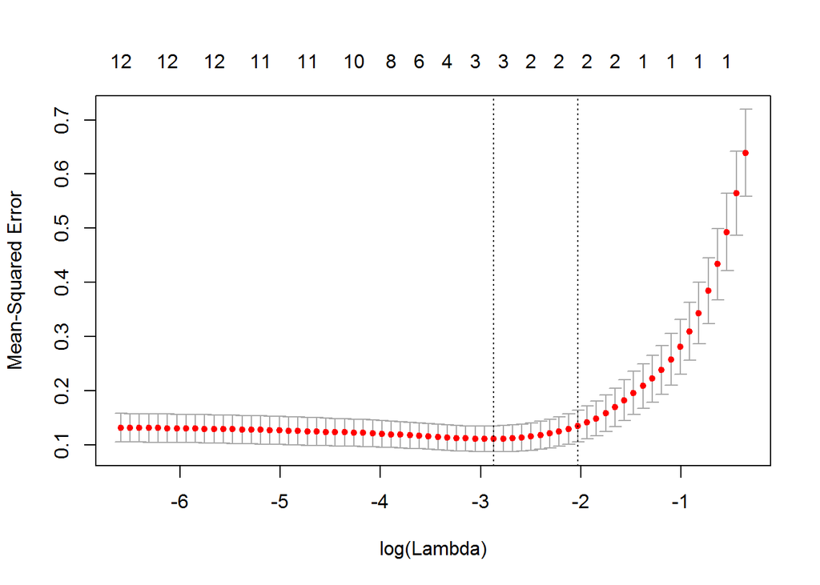

```r
xm <- model.matrix(LS ~., data=xmat)[,-1]
y <- xmat[,"LS"]
xm.tr <- xm[1:94,]
y.tr <-  y[1:94]
xm.te <- xm[95:104,]
y.te <-  y[95:104]
#
set.seed(1)
m.L <- cv.glmnet(x=xm.tr, y=y.tr,  alpha=1)
plot(m.L)
```

```r
L.min <- m.L$lambda.min
L.1se <- m.L$lambda.1se
coefficients(m.L, s=c(L.min,L.1se))
```

```
## 19 x 2 sparse Matrix of class "dgCMatrix"
##                       1          2
## (Intercept)  6.71734672  6.5189455
## S.WF_LSA     0.08012381  .
## S.WF_MSA     .           .
## S.WF_SSA     .           .
## S.WD_MIN     0.42675950  0.2546119
## S.WD_MAJ     .           .
## A.PPU       -2.37109902 -2.1178784
## S.WF_LSA.1   .           .
## S.WF_MSA.1   .           .
## S.WF_SSA.1   .           .
## S.WD_MIN.1   .           .
## S.WD_MAJ.1   .           .
## A.PPU.1      .           .
## S.WF_LSA.2   .           .
## S.WF_MSA.2   .           .
## S.WF_SSA.2   .           .
## S.WD_MIN.2   .           .
## S.WD_MAJ.2   .           .
## A.PPU.2      .           .
```

2. (5 pts) Use the training set to fit an unrestricted regression model (i.e., lm(â¦) ) on the reduced set of explanatory variables identified by The Lasso. Report the coefficients of the full model and comment on the fit of the model and examine the auto-correlations of the residuals of this model.

```r
md.SK <- lm(y ~ xm[,c(4,6)])
summary(md.SK)
```

```
##
## Call:
## lm(formula = y ~ xm[, c(4, 6)])
##
## Residuals:
##     Min      1Q  Median      3Q     Max
## -0.9165 -0.1804  0.0126  0.2175  0.8580
##
## Coefficients:
##                       Estimate Std. Error t value Pr(>|t|)
## (Intercept)            6.92852    0.12299  56.333  < 2e-16 ***
## xm[, c(4, 6)]S.WD_MIN  0.52246    0.09651   5.413 4.19e-07 ***
## xm[, c(4, 6)]A.PPU    -2.58119    0.12667 -20.378  < 2e-16 ***
## ---
## Signif. codes:  0 '***' 0.001 '**' 0.01 '*' 0.05 '.' 0.1 ' ' 1
##
## Residual standard error: 0.3307 on 101 degrees of freedom
## Multiple R-squared:  0.829,  Adjusted R-squared:  0.8256
## F-statistic: 244.8 on 2 and 101 DF,  p-value: < 2.2e-16
```

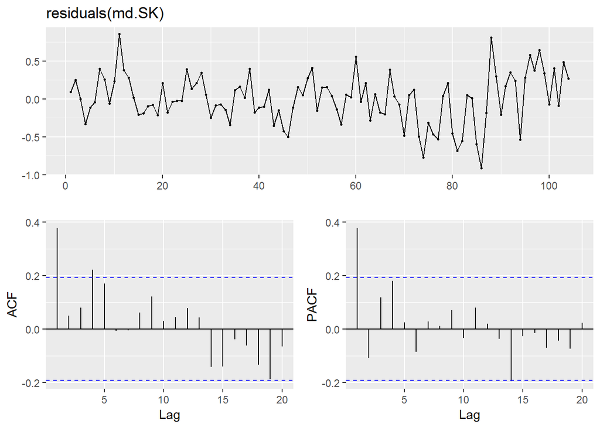

```r
ggtsdisplay(residuals(md.SK))
```

*The coefficients of the “Minor In-Store Display” variable, and of the “Price Elasticity” parameter are signifficant in the unconstrained (plain) regression, but the residuals show auto-correlation. Hence the model is not valid.*

3. (5 pts) Fit an ARIMA model to explain the training set log-of-sales-volume data. Report the diagnostic of your modelâs residuals and comment on the modelâs validity.

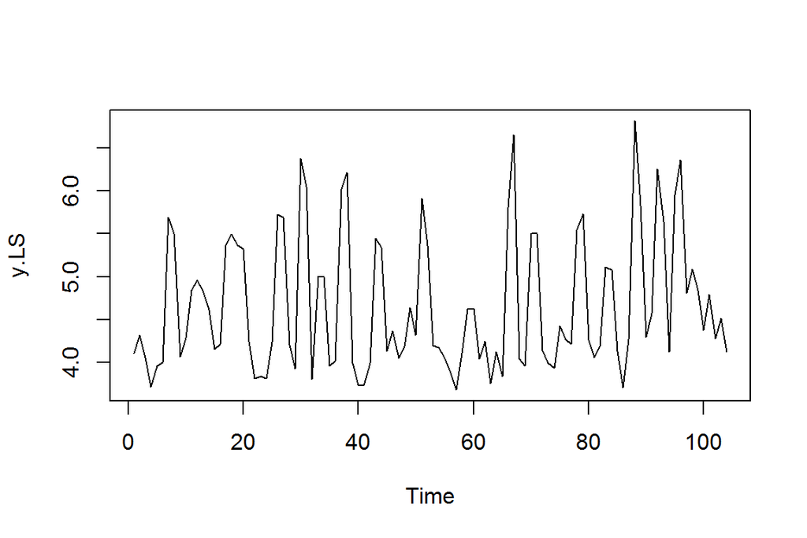

```r
y.LS <- ts(y, start=1)
y.tr <- window(y.LS, end=94)
y.te <- window(y.LS, start=95)
plot(y.LS)
```

```r
maa.SK = auto.arima(y.tr)
summary(maa.SK)
```

```
## Series: y.tr
## ARIMA(2,0,1) with non-zero mean
##
## Coefficients:
##          ar1      ar2     ma1    mean
##       0.0363  -0.3600  0.5797  4.6322
## s.e.  0.1711   0.1271  0.1818  0.0778
##
## sigma^2 estimated as 0.4153:  log likelihood=-90.51
## AIC=191.02   AICc=191.7   BIC=203.73
##
## Training set error measures:
##                         ME      RMSE      MAE       MPE     MAPE     MASE
## Training set -0.0001286775 0.6305537 0.474108 -1.696712 10.05719 0.726594
##                      ACF1
## Training set -0.004242972
```

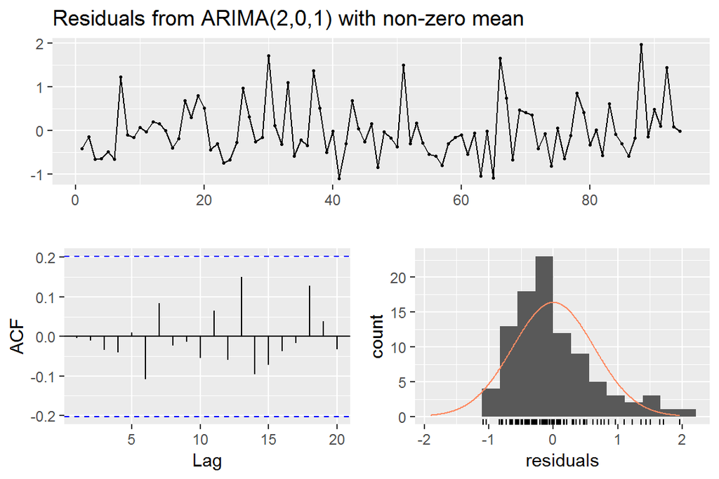

```
##
##  Ljung-Box test
##
## data:  Residuals from ARIMA(2,0,1) with non-zero mean
## Q* = 2.6269, df = 6, p-value = 0.854
##
## Model df: 4.   Total lags used: 10
```

```r
checkresiduals(maa.SK)
```

4. (5 pts) Use the model in Question 3 to prepare a 10 period ahead forecast and compare it (overly it) with the testing set log-of-sales data. Comment on the usefulness of this model in terms of precision and confidence interval.

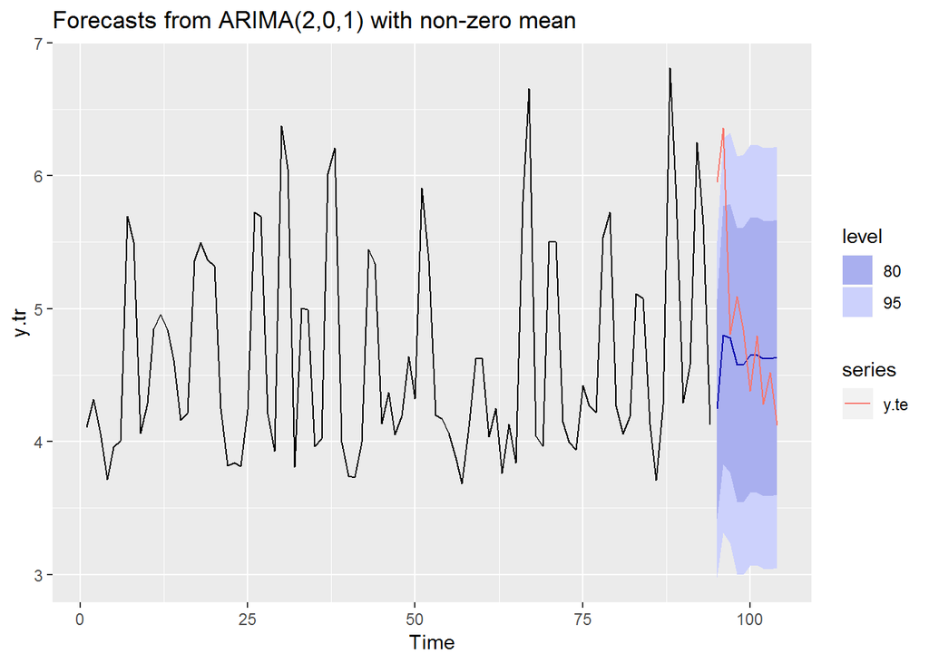

```r
fc.SK <- forecast(maa.SK, h=10)
autoplot(fc.SK) + autolayer(y.te)
```

*Although in the previous question we determined that he model is valid, it is not very useful for prediction as the confidence interval exposes two shortcomings of this model:*  
*(1) It is too wide; it ranges over all the previously observed demands, and*  
*(2) it is not granular enough; it fails to indicate in advance if the demand will increase or decrease.*

5. (5 pts) Use the auto.arima(â¦) function to fit a dynamic regression model to explain sales data (log) using only the predictive variables identified by The Lasso in Question 1. Examine the modelâs residuals and comment on its validity.

```r
maa.SKX <- auto.arima(y.tr, xreg=xm.tr[,c(4,6)])
summary(maa.SKX)
```

```
## Series: y.tr
## Regression with ARIMA(0,0,1) errors
##
## Coefficients:
##          ma1  intercept  S.WD_MIN    A.PPU
##       0.5109     6.9871    0.3591  -2.6548
## s.e.  0.0942     0.1340    0.0928   0.1341
##
## sigma^2 estimated as 0.08464:  log likelihood=-15.43
## AIC=40.86   AICc=41.54   BIC=53.58
##
## Training set error measures:
##                        ME      RMSE       MAE        MPE     MAPE
## Training set -0.000157446 0.2846773 0.2242023 -0.3514288 4.941856
##                   MASE       ACF1
## Training set 0.3436012 0.04571852
```

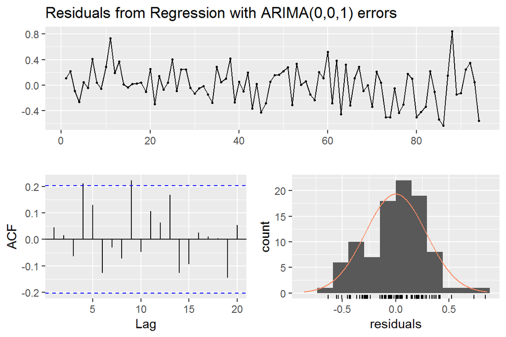

```
##
##  Ljung-Box test
##
## data:  Residuals from Regression with ARIMA(0,0,1) errors
## Q* = 14.614, df = 6, p-value = 0.02348
##
## Model df: 4.   Total lags used: 10
```

```r
checkresiduals(maa.SKX)
```

6. (5 pts) Obtain a dynamic regression model that improves on the auto-arima model in Question 5 in terms of its information coefficients and residual diagnostics. Compare the coefficients of the explanatory variables in (a) The Lasso model, (b) The unrestricted model obtained in Question 2, and (c) The ones obtained in this question. Then use the B notation (polynomial) to describe the model you obtained.

```r
#
# After some experimentation, I settled on the model below
# your answer may differ on the order of the model
#
m.SKX <- Arima(y.tr, order=c(3,0,2), xreg=xm.tr[,c(4,6)], include.constant = TRUE)
ggtsdisplay(diff(arima.errors(m.SKX)))
```

```
## Deprecated, use residuals.Arima(object, type='regression') instead
```

[figure not shown]

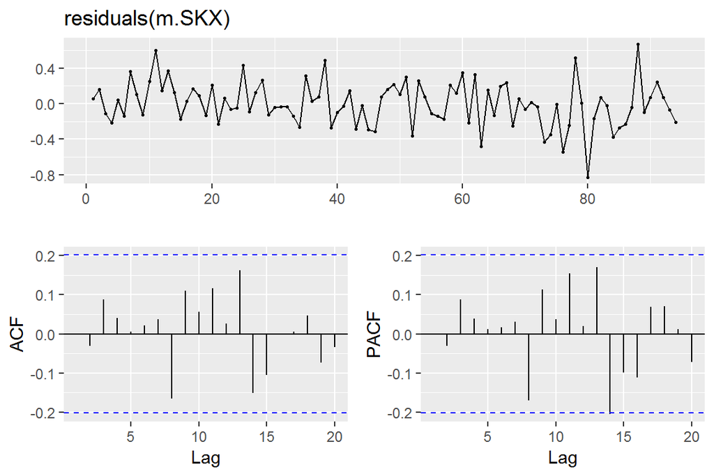

```r
ggtsdisplay(residuals(m.SKX))
```

```r
summary(m.SKX)
```

```
## Series: y.tr
## Regression with ARIMA(3,0,2) errors
##
## Coefficients:
##          ar1      ar2     ar3     ma1     ma2  intercept  S.WD_MIN
##       0.4957  -0.9876  0.3875  0.1324  1.0000     6.9242    0.2438
## s.e.  0.1171   0.0544  0.1109  0.0540  0.0603     0.0954    0.0809
##         A.PPU
##       -2.5624
## s.e.   0.0839
##
## sigma^2 estimated as 0.06831:  log likelihood=-6.49
## AIC=30.98   AICc=33.13   BIC=53.87
##
## Training set error measures:
##                        ME      RMSE       MAE        MPE     MAPE
## Training set 2.640112e-06 0.2500009 0.1945773 -0.2918471 4.271454
##                   MASE         ACF1
## Training set 0.2981994 0.0007862222
```

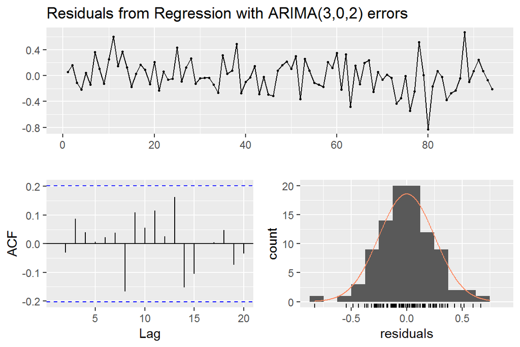

```
##
##  Ljung-Box test
##
## data:  Residuals from Regression with ARIMA(3,0,2) errors
## Q* = 14.96, df = 11, p-value = 0.1844
##
## Model df: 8.   Total lags used: 19
```

```r
checkresiduals(m.SKX, lag=19)
```

*Coefficient Comarison:*

[output not shown]

*The estimate of the price elasticity of demand is closer between the Dinamic Regression and the plain Regression model, but the autocorrelation was causing an overestimation of the effgect of in-store displays on log-of-demand.*

*Model Description in B-Notation:*
$$ln(y_t) = \beta_0 + \beta_1 S.WD.MIN + \beta_2 ln(A.PPU) +n_t$$
$$(1-\phi_1 B - \phi_2 B^2 - \phi_3B^3)n_t = (1+\theta_1B + \theta_2 B^2)e_t$$

7. (5 pts) Use the model in Question 5 to prepare a 10 period ahead forecast and compare it (overly it) with the testing set log-of-sales data. Comment on the usefulness of this model in terms of precision and confidence interval relative to the model without explanatory variables in Question 3.

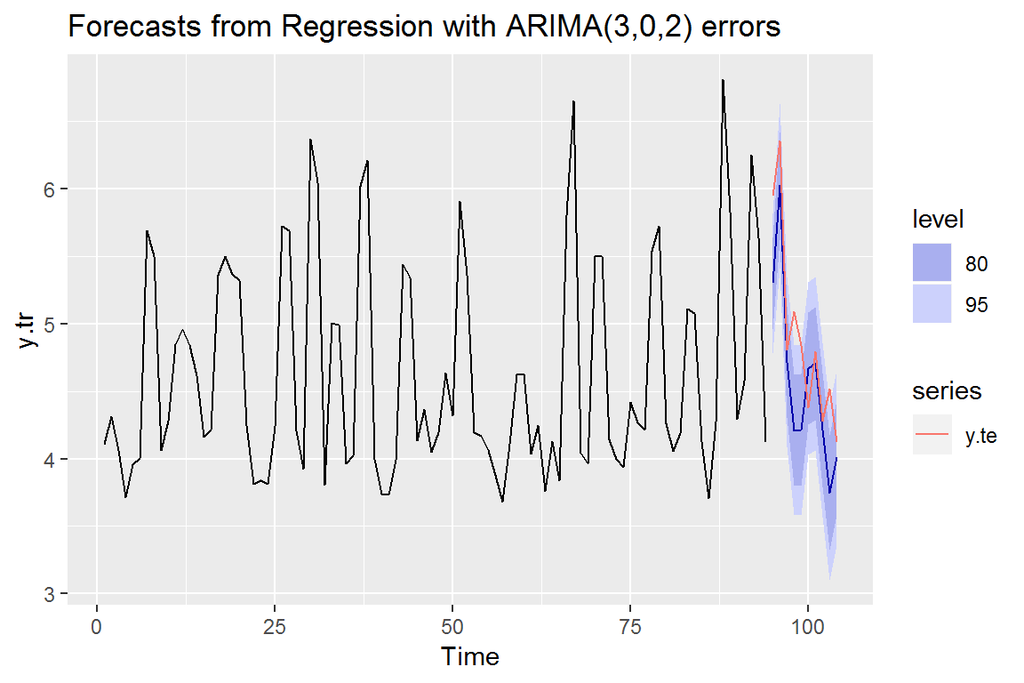

```r
#
# I am displaying the model is Question 6
# Forecasts from the model in Question 5 are somehat similar
#
fc <- forecast(m.SKX, h=10, xreg=xm.te[,c(4,6)])
autoplot(fc) + autolayer(y.te)
```

```r
accuracy(fc,y.te)
```

```
##                        ME      RMSE       MAE        MPE     MAPE
## Training set 2.640112e-06 0.2500009 0.1945773 -0.2918471 4.271454
## Test set     3.318033e-01 0.4902401 0.3900020  6.4637614 7.792820
##                   MASE          ACF1 Theil's U
## Training set 0.2981994  0.0007862222        NA
## Test set     0.5976975 -0.1169092629 0.8972498
```

*Although this model is significantly more useful than the plain ARIMA model, you get the impression that this model still has room for improvement. In particular, there appears to be either additional effects not captured bu thye model or the type of aggregation used to dveelop this model averages-out (neutralizes) the predictive value of the variables (features) used.*

8. (5 pts) After you complete a project, it is often useful to reflect on what would you different if you were to perform this project again. This is no exception. Comment on the training and testing fit statistics and discuss how do you think you could improve on the performance of the model in terms of (a) additional data, (b) different pre-processing of the existing data, and (c) different modeling choices. Discuss your assessment of the potential for improvement (ex-ante priorities) for the different improvement options you suggest.

*If we were to perform this project again we may consider (among others) the following:*

1. *Additional Data:*
   1. Advertising expenditures in mass media
   2. Other promotional activities outside the store
2. *Different Preprocessing:*
   1. Different aggregation of SKUs (i.e., crunchy, creamy, flavored)
   2. A higher level of aggregation of advertising variables (some forms of advertising are seldom used)
3. *Modeling Choices:*
   1. Possible effect of weather (temperature) on consumption patterns.
   2. Shifts in demand as a consequence of business (new or closing of a competitor-store) or economic environment (unemplyment, recession)